Adam Reis || ahr2127

# Lab 4: Refractive Indices and Wavelengths

### Introduction:

In this lab, we measured the wavelength of a Helium-Neon laser using two configurations: Fabry-Perot (617 +/- 57 nm) and Michelson (628 +/- 22.82 nm). We then measured the refractive index of of air (1.0008) and glass (1.34 +/- 0.011).

### Results:

I left in all the code, so you can see exactly what we calculated. All important values are either shown on the graph or are printed. Note that the graph does have error bars for both axes, although they may not be visible.

```python
micrometer_reading = 520
```

### Measurement of Laser Wavelength (Fabry-Perot Mode)

```python
import numpy as np

fp_m = 20 # number of fringes
micrometer_error = 0.1*10**-6 # microns -> meters
fp_micrometer_readings = [
    # (starting point, distance travelled) microns
    (500, 5.2),
    (505, 6.1),
    (515, 6.0),
    (525, 5.3),
    (530, 5.9),
    (535, 6.3),
    (540, 6.9),
    (545, 6.3),
    (550, 6.8),
    (555, 6.9),
]

fp_d_m = [m*10**-6 for _, m in fp_micrometer_readings]
fp_wavelengths = np.array([2*d/fp_m for d in fp_d_m])
fp_wavelength_mean = np.mean(fp_wavelengths)
fp_wavelength_std = np.std(fp_wavelengths)

print("Fabry-Perot wavelength: {} +/- {}M".format(fp_wavelength_mean, fp_wavelength_std))
```

```
Fabry-Perot wavelength: 6.17e-07 +/- 5.74543296889e-08M
```

### Measurement of Laser Wavelength (Michelson Mode)

```python
mm_m = 20
mm_micrometer_readings = [
    # (starting point, distance travelled) microns
    (507.2, 6.3),
    (513.5, 6.2),
    (519.7, 6.3),
    (526.0, 6.1),
    (532.1, 6.05),
    (538.15, 6.35),
    (544.8, 6.9),
    (551.7, 6.2),
    (565.0, 6.1),
    (571.1, 6.3),
]

mm_d_m = [m*10**-6 for _, m in mm_micrometer_readings]
mm_wavelengths = [2*d/mm_m for d in mm_d_m]
mm_wavelength_mean = np.mean(mm_wavelengths)
mm_wavelength_std = np.std(mm_wavelengths)

print("Michelson Mode wavelength: {} +/- {}M".format(mm_wavelength_mean, mm_wavelength_std))

# It looks like this is a bit more accurate, so we'll use it for future calculations
```

```
Michelson Mode wavelength: 6.28e-07 +/- 2.2825424421e-08M
```

### Measurement of Index of Refraction of Air

```python
air_reading_error = 0.1

air_readings = [
    # (rings (m), cm Hg)
    (2, 9),
    (3, 15),
    (2, 10),
    (2, 10),
    (1, 6),
    (1, 6.3),
    (3, 14),
]
```

```python
# use eq 6.2 to convert these values of m to n - n_atm
p_atm = 76 # cm Hg
p_vacuum = 0 # cm Hg
d = 3*10**-2 # cm -> m
lambda_0 = 632.8*10**-9

dP = [p-76 for _, p in air_readings]
dP_err = air_reading_error
dn = [(p * lambda_0)/(2 * d) for _, p in air_readings]
dn_err = (air_reading_error * lambda_0)/(2 * d)
```

```python
import numpy as np

def lsqfity(X, Y):
    """
    Copied from http://stackoverflow.com/questions/27764220/retrieve-the-standard-deviation-of-the-y-intercept
    Calculate a "MODEL-1" least squares fit.

    The line is fit by MINIMIZING the residuals in Y only.

    The equation of the line is:     Y = my * X + by.

    Equations are from Bevington & Robinson (1992)
    Data Reduction and Error Analysis for the Physical Sciences, 2nd Ed."
    pp: 104, 108-109, 199.

    Data are input and output as follows:

    my, by, ry, smy, sby = lsqfity(X,Y)
    X     =    x data (vector)
    Y     =    y data (vector)
    my    =    slope
    by    =    y-intercept
    ry    =    correlation coefficient
    smy   =    standard deviation of the slope
    sby   =    standard deviation of the y-intercept

    """

    X, Y = map(np.asanyarray, (X, Y))

    # Determine the size of the vector.
    n = len(X)

    # Calculate the sums.

    Sx = np.sum(X)
    Sy = np.sum(Y)
    Sx2 = np.sum(X ** 2)
    Sxy = np.sum(X * Y)
    Sy2 = np.sum(Y ** 2)

    # Calculate re-used expressions.
    num = n * Sxy - Sx * Sy
    den = n * Sx2 - Sx ** 2

    # Calculate my, by, ry, s2, smy and sby.
    my = num / den
    by = (Sx2 * Sy - Sx * Sxy) / den
    ry = num / (np.sqrt(den) * np.sqrt(n * Sy2 - Sy ** 2))

    diff = Y - by - my * X

    s2 = np.sum(diff * diff) / (n - 2)
    smy = np.sqrt(n * s2 / den)
    sby = np.sqrt(Sx2 * s2 / den)

    return my, by, ry, smy, sby
```

```
n_air: 1.00080154667
```

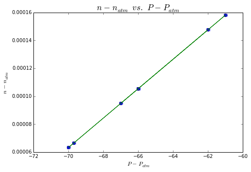

```python
%matplotlib inline

import matplotlib.pyplot as plt

fig = plt.figure()

axes = fig.add_axes([0, 0, 1, 1])

axes.set_title('$n\ -\ n_{atm}\ \ vs.\ \ P\ -\ P_{atm}$', size='xx-large')
axes.set_xlabel('$P\ -\ P_{atm}$', size='large')
axes.set_ylabel('$n\ -\ n_{atm}$', size='large')

A, D, r_coef, dA, dD = lsqfity(dP, dn)
fit_fn = np.poly1d((A, D))

n_air = 1 + D
print('n_air: {}'.format(n_air))

axes.errorbar(dP, dn, yerr=dn_err, xerr=dP_err, fmt='o')
axes.plot(dP, fit_fn(dP))

axes.legend(loc=2)
```

### Measurement of Index of Refraction of Glass

```python
glass_thickness = 5.6*10**-3 # mm -> M
angle_error = .1
readings_error = 3

"""
Every time anyone in the lab moved a chair, the rings jumped around.
Thus, it's possible that we missed a ring or two (in either direction)
every time that happened. It also made it really straining to keep
counting, so we weren't able to get to a full 10 degrees each time.
"""
glass_readings = [
    # (rings, theta)
    (71, 10),
    (70, 10),
    (68, 10),
    (66, 10),
    (69, 10)
]
```

```python
from math import sin, cos, radians

n_air = 1.000293
d = glass_thickness
n_glass_measurements = []

d_n = [m*632.8/60000000 for m, _ in glass_readings]

for m, theta in glass_readings:
    n_glass_num = n_air * (2*d*n_air - m*lambda_0)*(1 - cos(radians(theta)))
    n_glass_den = 2*d*n_air*(1 - cos(radians(theta))) - m*lambda_0

    n_glass_measurements.append(float(n_glass_num)/float(n_glass_den))

n_glass_measurements = np.array(n_glass_measurements)
n_glass_mean = np.mean(n_glass_measurements)
n_glass_std = np.std(n_glass_measurements)
print('n_glass = {} +/- {}'.format(n_glass_mean, n_glass_std))
```

```
n_glass = 1.33897899396 +/- 0.0113405086653
```

### Analysis:

##### Compare the results from the two separate methods [for measuring the wavelength of the laser]. Do they agree within uncertainties? Does one method appear to be more accurate than the other?

Yes! For once, both values gree with their uncertanties. The Michelson method yielded a result that was closer to the expected value (632.8 nm), with a lower error.

##### Does your value for n ̄glass seem reasonable? For example, the index of refraction of crown glass is n = 1.52.

Yep. Ours is smaller than that, but seems to be in the right ballpark.

##### What is the smallest distance scale that can be measured by the Fabry-Perot interferometer? Which is better, the Michelson or the Fabry-Perot? Why?

The smallest distance scale that can be measured by the Fabry-Perot interferometer is in nanometers. Our data suggests that the Michelson interferometer appears to be more accurate, because our results were more consistent, and closer to the expected value.

##### How could you change either of these interferometers to measure smaller distance scales? What if you wanted to use the same equipment as you had in this experiment?

We could measure smaller distance scales either by using light with a higher wavelength (like violet), so that the interference would form many smaller dark fringes, or by using more mirrors to split the beam such that we get only a very small fraction of the wave pattern containing the fringes.